# Pedicting Excercice Performance

Nehal El-Zayat

9 August 2017

# Introduction

The purpose of this project is to predict the level of performance of certain excercices from data collected from wearable devices during physical training.

# Loading and Exploring Data

In this section, we load the libraried needed throughout the analysis and the training and the testing data sets. We also explore the data in the training set, to get a better perspective on the nature of the data and which variables would be beneficial for the prediction model.

```r
library(caret)
library(parallel)
library(doParallel)
library(randomForest)

training<- read.csv("pml-training.csv")
testing<- read.csv("pml-testing.csv")
```

```r
summary(training)
```

```r
head(training)
```

```
##   X user_name raw_timestamp_part_1 raw_timestamp_part_2   cvtd_timestamp
## 1 1  carlitos           1323084231               788290 05/12/2011 11:23
## 2 2  carlitos           1323084231               808298 05/12/2011 11:23
## 3 3  carlitos           1323084231               820366 05/12/2011 11:23
## 4 4  carlitos           1323084232               120339 05/12/2011 11:23
## 5 5  carlitos           1323084232               196328 05/12/2011 11:23
## 6 6  carlitos           1323084232               304277 05/12/2011 11:23
##   new_window num_window roll_belt pitch_belt yaw_belt total_accel_belt
## 1         no         11      1.41       8.07    -94.4                3
## 2         no         11      1.41       8.07    -94.4                3
## 3         no         11      1.42       8.07    -94.4                3
## 4         no         12      1.48       8.05    -94.4                3
## 5         no         12      1.48       8.07    -94.4                3
## 6         no         12      1.45       8.06    -94.4                3
##   kurtosis_roll_belt kurtosis_picth_belt kurtosis_yaw_belt
```

[output cut: 265 more lines]

```r
table(training$classe)
```

```
##
##    A    B    C    D    E
## 5580 3797 3422 3216 3607
```

# Cleaning Data

The data collected should be first cleaned and prepared in order to create an effective prediction model.

First, we removed the columns that represents feature about the person who applied the exercice, like his ID or name. The purpose of this move is to make the prediction unbias to the user.

Second, it was observed from data exploration that many columns have NA values. The following code calculates the percentage of NAs in columns and eliminates the columns with high NAs values since they don’t have an impact on the prediction model.

```r
index<- vector()
j<- 1
for (i in 8:160){
  if(sum(is.na(training[,i]))/19622 < 0.2){
    index[j]<- i
      j<- j+1
  }

}
train_set<- training[, index]
```

After removing the columns with high NAs percentage, the next step is to remove the columns that have near zero variance, because, as NA case, they won’t have an impact on the prediction model since the value is approximity unique throughout the whole data set.

```r
nsv<- nearZeroVar(training,saveMetrics = TRUE)
temp_col<- nsv[which(nsv$nzv == FALSE),]
names<- rownames(temp_col)

final_predictor<- train_set[,which(colnames(train_set) %in% names)]
```

To make the test data compatible with the model, we apply the same operations on the test set, using the features of the training data.(Removing the same exact columns)

```r
test_set<- testing[,index]
final_test<- test_set[,which(colnames(test_set)%in% names)]
```

# Prediction Model and Cross-Validation

Using the traincontrol() method, we set the cross-validation settings for the training data. We set the number to be equal to 4, not larger since we are limited in the computation capacity.

```r
fitcontrol <- trainControl(method = "cv",
                                       number = 4,
                                       allowParallel = TRUE)
```

We select the Random Forest Algorithm to create the prediction model. However, before creating the model, given the computation limitations, we have to make R work in multithread instead of single thread to be able to get the resulting model in a reasonable timing.

```r
cluster<- makeCluster(detectCores()-1)
registerDoParallel(cluster)
```

```r
modal<- train(classe~., data=final_predictor, method="rf",trContorl = fitcontrol)

#closing the cluster
stopCluster(cluster)
registerDoSEQ()
```

# Results

After developing the model, we test it first on the training set.

```r
predict_train<- predict(modal, final_predictor)
confusionMatrix(final_predictor$classe, predict(modal, final_predictor))
```

```
## Confusion Matrix and Statistics
##
##           Reference
## Prediction    A    B    C    D    E
##          A 5580    0    0    0    0
##          B    0 3797    0    0    0
##          C    0    0 3422    0    0
##          D    0    0    0 3216    0
##          E    0    0    0    0 3607
##
## Overall Statistics
##
##                Accuracy : 1
##                  95% CI : (0.9998, 1)
##     No Information Rate : 0.2844
##     P-Value [Acc > NIR] : < 2.2e-16
##
##                   Kappa : 1
##  Mcnemar's Test P-Value : NA
##
## Statistics by Class:
##
##                      Class: A Class: B Class: C Class: D Class: E
## Sensitivity            1.0000   1.0000   1.0000   1.0000   1.0000
## Specificity            1.0000   1.0000   1.0000   1.0000   1.0000
## Pos Pred Value         1.0000   1.0000   1.0000   1.0000   1.0000
## Neg Pred Value         1.0000   1.0000   1.0000   1.0000   1.0000
## Prevalence             0.2844   0.1935   0.1744   0.1639   0.1838
## Detection Rate         0.2844   0.1935   0.1744   0.1639   0.1838
## Detection Prevalence   0.2844   0.1935   0.1744   0.1639   0.1838
## Balanced Accuracy      1.0000   1.0000   1.0000   1.0000   1.0000
```

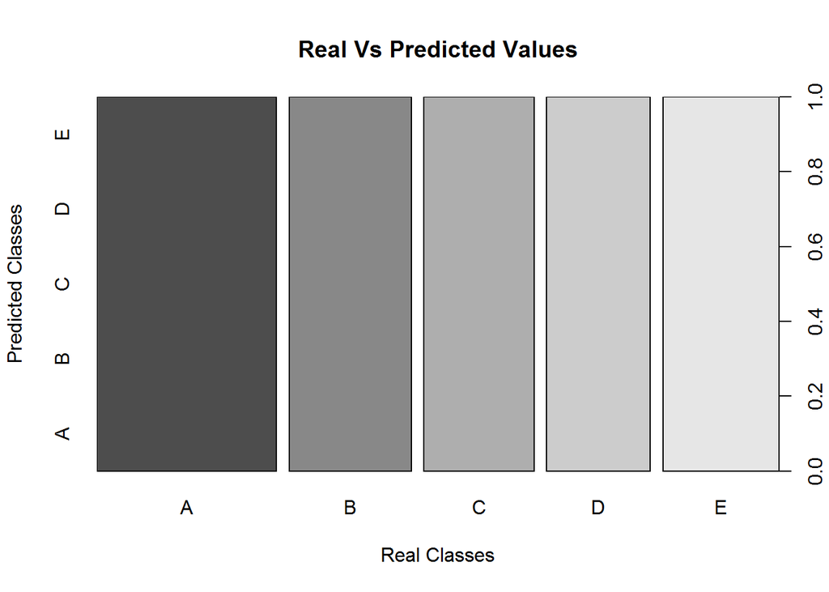

```r
plot(final_predictor$classe, predict_train, main= "Real Vs Predicted Values", xlab= "Real Classes", ylab= "Predicted Classes")
```

From the plot we can see that the prediction has a 100% accuracy on the training set.

Now we implement the model on the test set.

```r
results<- predict(modal, final_test)
```